# Prophet-July7

### 1.Load data

Fbprophet implements a Generalized Additive Model, and - in a nutshell - models a time-series as the sum of different components (non-linear trend, periodic components and holidays or special events) and allows to incorporate extra-regressors (categorical or continuous). The reference is Taylor and Letham, 2017 and this blog. https://nbviewer.org/github/nicolasfauchereau/Auckland_Cycling/blob/master/notebooks/Auckland_cycling_and_weather.ipynb

```python
import pandas as pd
import matplotlib.pyplot as plt
import seaborn as sns
import numpy as np
# Load the dataset
df_canada_data = pd.read_excel('/Users/zhangliuting/Downloads/Dissertation/(1)Canada.xlsx')

# Convert date field from string to datetime
df_canada_data['Month'] = pd.to_datetime(df_canada_data['Month'])

print(df_canada_data.head())
print(df_canada_data.tail())
```

```
       Month  Vehicle Sales    Import  Gasoline  Electricity Price  \
0 2017-01-01         112996   7957105     112.2              102.2
1 2017-02-01         125284   9095184     106.5              109.5
2 2017-03-01         190744  10686981     106.0              105.5
3 2017-04-01         200291   9925780     116.1              100.4
4 2017-05-01         220436  10903984     110.9              106.4

   Employment Rate    CPI  Car Rebate Index  Remote Work Index
0             61.6  129.5                16                 37
1             61.7  129.7                21                 31
2             61.7  129.9                21                 32
3             61.7  130.4                25                 27
4             61.7  130.5                18                 26
        Month  Vehicle Sales    Import  Gasoline  Electricity Price  \
79 2023-08-01         159668  13152208     170.6              141.7
80 2023-09-01         164168  13221105     168.3              138.3
81 2023-10-01         151978  12523025     157.4              130.6
82 2023-11-01         144634  12180276     152.2              129.4
83 2023-12-01         128827  10497505     145.4              133.7

    Employment Rate    CPI  Car Rebate Index  Remote Work Index
79             62.0  158.7                38                 92
80             62.0  158.5                34                 89
81             61.9  158.6                38                 91
82             61.8  158.8                26                 96
83             61.7  158.3                27                 86
```

### 2.EDA

```python
df_canada_data.shape
```

```
(84, 9)
```

```python
df_canada_data.info()
```

```
<class 'pandas.core.frame.DataFrame'>
RangeIndex: 84 entries, 0 to 83
Data columns (total 9 columns):
 #   Column             Non-Null Count  Dtype
---  ------             --------------  -----
 0   Month              84 non-null     datetime64[ns]
 1   Vehicle Sales      84 non-null     int64
 2   Import             84 non-null     int64
 3   Gasoline           84 non-null     float64
 4   Electricity Price  84 non-null     float64
 5   Employment Rate    84 non-null     float64
 6   CPI                84 non-null     float64
 7   Car Rebate Index   84 non-null     int64
 8   Remote Work Index  84 non-null     int64
dtypes: datetime64[ns](1), float64(4), int64(4)
memory usage: 6.0 KB
```

```python
df_canada_data.describe()
```

|  | Month | Vehicle Sales | Import | Gasoline | Electricity Price | Employment Rate | CPI | Car Rebate Index | Remote Work Index |
| --- | --- | --- | --- | --- | --- | --- | --- | --- | --- |
| count | 84 | 84.000000 | 8.400000e+01 | 84.000000 | 84.000000 | 84.000000 | 84.000000 | 84.000000 | 84.000000 |
| mean | 2020-06-16 01:08:34.285714176 | 151205.083333 | 9.509810e+06 | 130.948810 | 117.511905 | 61.259524 | 140.958333 | 34.666667 | 54.500000 |
| min | 2017-01-01 00:00:00 | 47508.000000 | 2.385315e+06 | 77.800000 | 100.400000 | 51.900000 | 129.500000 | 13.000000 | 26.000000 |
| 25% | 2018-09-23 12:00:00 | 125325.250000 | 8.382993e+06 | 112.200000 | 110.550000 | 61.525000 | 133.675000 | 24.000000 | 33.000000 |
| 50% | 2020-06-16 00:00:00 | 151960.500000 | 9.380096e+06 | 125.450000 | 114.900000 | 61.950000 | 137.100000 | 30.000000 | 50.000000 |
| 75% | 2022-03-08 18:00:00 | 176541.250000 | 1.073832e+07 | 147.075000 | 121.575000 | 62.200000 | 149.125000 | 41.250000 | 80.000000 |
| max | 2023-12-01 00:00:00 | 220858.000000 | 1.322110e+07 | 207.200000 | 147.600000 | 62.500000 | 158.800000 | 100.000000 | 100.000000 |
| std | NaN | 33699.871309 | 1.851021e+06 | 25.510685 | 9.645092 | 1.858301 | 9.253110 | 16.260184 | 23.430235 |

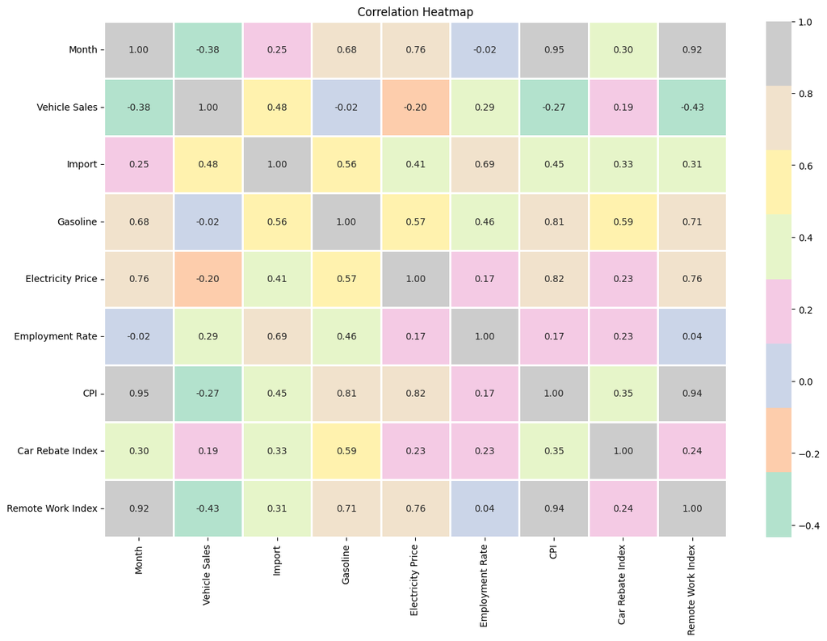

```python
# Correlation
plt.figure(figsize=(15, 10))

# Using Seaborn to create a heatmap
sns.heatmap(df_canada_data.corr(), annot=True, fmt='.2f', cmap='Pastel2', linewidths=2)

plt.title('Correlation Heatmap')
plt.show()
```

### Prophet Trial

#### Prepare the data and subsets (train and test set)

```python
# Function to split and prepare data for Prophet with additional regressors
def prepare_data_for_prophet_with_regressors(df, date_column, forecast_column, additional_columns, train_start, train_end, test_start, test_end):
    # Filter the data for training and testing periods
    train_data = df[(df[date_column] >= train_start) & (df[date_column] <= train_end)]
    test_data = df[(df[date_column] >= test_start) & (df[date_column] <= test_end)]

    # Select the necessary columns for Prophet: 'ds' for datestamp, 'y' for the forecast variable, and other features
    train_columns = [date_column, forecast_column] + additional_columns
    test_columns = [date_column, forecast_column] + additional_columns

    # Rename columns to fit Prophet's format
    train_data = train_data[train_columns].rename(columns={date_column: 'ds', forecast_column: 'y'})
    test_data = test_data[test_columns].rename(columns={date_column: 'ds', forecast_column: 'y'})

    return train_data, test_data

# List of regressors
additional_columns = ['Import', 'Gasoline', 'Electricity Price', 'Employment Rate', 'CPI', 'Car Rebate Index', 'Remote Work Index']

# Using the function to get the train and test data
data_train, data_test = prepare_data_for_prophet_with_regressors(
    df_canada_data, 'Month', 'Vehicle Sales', additional_columns, '2017-01-01', '2022-12-31', '2023-01-01', '2023-12-31'
)

print(data_train.tail())
print(data_test.head())
```

```
           ds       y    Import  Gasoline  Electricity Price  Employment Rate  \
67 2022-08-01  136815  11294410     169.6              132.4             62.0
68 2022-09-01  140094  10482272     156.4              124.0             61.9
69 2022-10-01  131085  10957424     171.5              117.0             62.0
70 2022-11-01  125339  11079350     165.3              122.3             62.1
71 2022-12-01  110271   9430645     143.6              135.8             62.2

      CPI  Car Rebate Index  Remote Work Index
67  152.6                51                 85
68  152.7                35                 81
69  153.8                36                 81
70  154.0                26                 97
71  153.1                27                 83
           ds       y    Import  Gasoline  Electricity Price  Employment Rate  \
72 2023-01-01  103355   9683303     150.3              134.8             62.4
73 2023-02-01  109799   9870624     148.5              141.4             62.4
74 2023-03-01  152943  12100629     150.3              129.3             62.3
75 2023-04-01  151335  11289457     160.1              128.8             62.3
76 2023-05-01  171889  12929832     158.8              126.3             62.2

      CPI  Car Rebate Index  Remote Work Index
72  153.9                45                100
73  154.5                37                 93
74  155.3                36                 93
75  156.4                46                 94
76  157.0                41                100
```

```python
print("data_train",data_train.shape)
print("data_test",data_test.shape)
```

```
data_train (72, 9)
data_test (12, 9)
```

```python
len(data_test)
```

```
12
```

#### Instantiate, then fit the model to the training data

The first step in fbprophet is to instantiate the model, it is there that you can set the prior scales for each component of your time-series, as well as the number of Fourier series to use to model the cyclic components.

A general rule is that larger prior scales and larger number of Fourier series will make the model more flexible, but at the potential cost of generalisation: i.e. the model might overfit, learning the noise (rather than the signal) in the training data, but giving poor results when applied to yet unseen data (the test data)

```python
from prophet import Prophet
import pandas as pd

# Initialize the Prophet model
m = Prophet(
    yearly_seasonality=20,
    seasonality_prior_scale=15.0,
    changepoint_prior_scale=0.1
)

# Add each regressor to the model
regressors = ['Import', 'Gasoline', 'Electricity Price', 'Employment Rate', 'CPI', 'Car Rebate Index', 'Remote Work Index']
for reg in regressors:
    m.add_regressor(reg, prior_scale=0.5, mode='multiplicative')

# Fit the model on the training dataset
m.fit(data_train)

# Instead of using make_future_dataframe, directly create a DataFrame with the dates from data_test
future = pd.DataFrame(data_test['ds'].values, columns=['ds'])

# Now assign regressor values since lengths should match
for reg in regressors:
    future[reg] = data_test[reg].values

# Confirm that the sizes match
print(future.shape)  # This should output (24, number of columns including regressors)
```

```
(12, 8)
```

```python
future.head()
```

|  | ds | Import | Gasoline | Electricity Price | Employment Rate | CPI | Car Rebate Index | Remote Work Index |
| --- | --- | --- | --- | --- | --- | --- | --- | --- |
| 0 | 2023-01-01 | 9683303 | 150.3 | 134.8 | 62.4 | 153.9 | 45 | 100 |
| 1 | 2023-02-01 | 9870624 | 148.5 | 141.4 | 62.4 | 154.5 | 37 | 93 |
| 2 | 2023-03-01 | 12100629 | 150.3 | 129.3 | 62.3 | 155.3 | 36 | 93 |
| 3 | 2023-04-01 | 11289457 | 160.1 | 128.8 | 62.3 | 156.4 | 46 | 94 |
| 4 | 2023-05-01 | 12929832 | 158.8 | 126.3 | 62.2 | 157.0 | 41 | 100 |

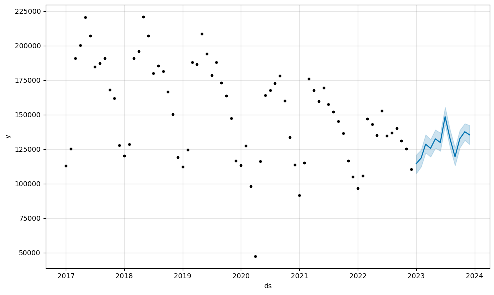

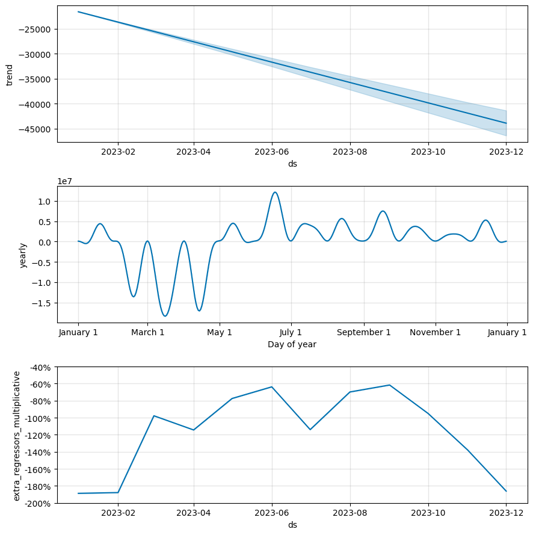

```python
# Plot the forecast and components
import matplotlib.pyplot as plt

# Predict using the future DataFrame with regressors
forecast = m.predict(future)

# Plotting
fig1 = m.plot(forecast)
plt.show()

fig2 = m.plot_components(forecast)
plt.show()
```

The predict method will assign each row in future a predicted value which it names yhat. If you pass in historical dates, it will provide an in-sample fit. The forecast object here is a new dataframe that includes a column yhat with the forecast, as well as columns for components and uncertainty intervals.

```python
from sklearn.metrics import mean_squared_error, mean_absolute_error

# Calculate RMSE
rmse = mean_squared_error(data_test['y'], forecast['yhat'].head(len(data_test)), squared=False)
print(f"Root Mean Squared Error: {rmse}")

# Calculate MAE
mae = mean_absolute_error(data_test['y'], forecast['yhat'].head(len(data_test)))
print(f"Mean Absolute Error: {mae}")
```

```
Root Mean Squared Error: 25497.3236886941
Mean Absolute Error: 21245.553313373293
```

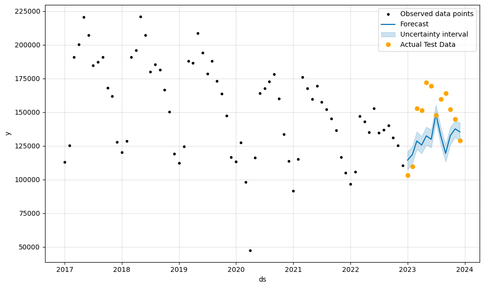

```python
# Plot the forecast
fig = m.plot(forecast)
ax = fig.gca()  # Get current axis

# Overlay the test data as orange dots
ax.plot(data_test['ds'], data_test['y'], 'o', color='orange', label='Actual Test Data')  # 'o' for dots

# Add legend to differentiate between predicted and actual values
plt.legend()

# Show the plot
plt.show()
```

#### make the verif pandas.DataFrame

```python
def make_verification_dataframe(forecast, data_test):
    """
    Create a verification dataframe by merging forecast data with actual data, including
    regressor predictions and their confidence intervals.

    Parameters:
    forecast (pd.DataFrame): The forecast dataframe output by Prophet that includes columns
                             like 'ds', 'yhat', 'yhat_lower', 'yhat_upper', and regressor
                             predictions and their bounds.
    data_test (pd.DataFrame): The actual data containing columns 'ds' and 'y' for actual values.

    Returns:
    pd.DataFrame: A merged dataframe with forecast, actual values, and regressor predictions
                  along with their diagnostic columns.
    """
    # Define the columns to extract from the forecast DataFrame, including regressors and their intervals
    columns = ['ds', 'yhat', 'yhat_lower', 'yhat_upper']
    regressors = ['Import', 'Gasoline', 'Electricity Price', 'Employment Rate', 'CPI', 'Car Rebate Index', 'Remote Work Index']
    for reg in regressors:
        columns.extend([f"{reg}", f"{reg}_lower", f"{reg}_upper"])

    # Select only the necessary columns from the forecast DataFrame
    forecast_subset = forecast[columns]

    # Merge forecast with actual data on the date column 'ds'
    verification_df = forecast_subset.merge(
        data_test[['ds', 'y']], on='ds', how='left'
    )

    # Calculate residuals (errors)
    verification_df['residuals'] = verification_df['y'] - verification_df['yhat']

    # Calculate percentage error
    verification_df['pct_error'] = (verification_df['residuals'] / verification_df['y']) * 100

    return verification_df


verification_df = make_verification_dataframe(forecast, data_test)
print(verification_df.head())
```

```
          ds           yhat     yhat_lower     yhat_upper    Import  \
0 2023-01-01  114425.211825  107322.077509  120842.083908  0.203271
1 2023-02-01  118545.030246  112284.315522  124522.632797  0.271158
2 2023-03-01  128567.110665  122376.515287  135478.444672  1.079332
3 2023-04-01  125582.994818  119417.306775  131984.700180  0.785356
4 2023-05-01  132433.703547  125830.220515  139031.873464  1.379843

   Import_lower  Import_upper  Gasoline  Gasoline_lower  Gasoline_upper  ...  \
0      0.203271      0.203271  0.322530        0.322530        0.322530  ...
1      0.271158      0.271158  0.298064        0.298064        0.298064  ...
2      1.079332      1.079332  0.322530        0.322530        0.322530  ...
3      0.785356      0.785356  0.455733        0.455733        0.455733  ...
4      1.379843      1.379843  0.438063        0.438063        0.438063  ...

   CPI_upper  Car Rebate Index  Car Rebate Index_lower  \
```

[output cut: 21 more lines]

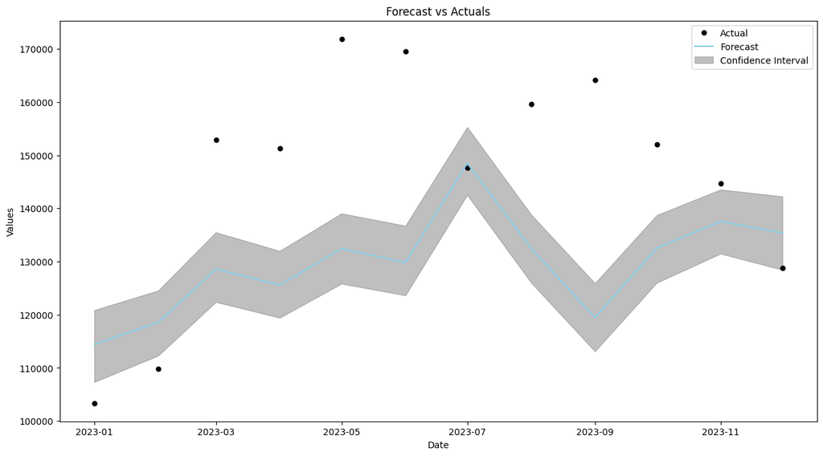

```python
import pandas as pd
import matplotlib.pyplot as plt

verification_df = make_verification_dataframe(forecast, data_test)

# Clip negative forecast values
verification_df['yhat'] = verification_df['yhat'].clip(lower=0)
verification_df['yhat_lower'] = verification_df['yhat_lower'].clip(lower=0)

# Plotting
plt.figure(figsize=(15, 8))
plt.plot(verification_df['ds'], verification_df['y'], 'ko', markersize=5, label='Actual')
plt.plot(verification_df['ds'], verification_df['yhat'], color='skyblue', label='Forecast')
plt.fill_between(verification_df['ds'], verification_df['yhat_lower'], verification_df['yhat_upper'], color='grey', alpha=0.5, label='Confidence Interval')
plt.title('Forecast vs Actuals')
plt.xlabel('Date')
plt.ylabel('Values')
plt.legend()
plt.show()
```

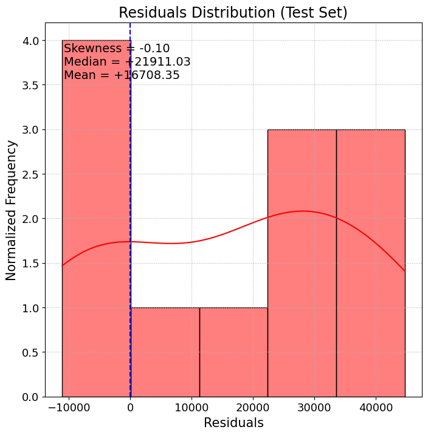

```python
import seaborn as sns
from scipy.stats import skew
import os

# Ensure the directory exists
figures_dir = "./figures/"
os.makedirs(figures_dir, exist_ok=True)

# Calculate residuals
verification_df['residuals'] = verification_df['y'] - verification_df['yhat']

# Create a plot of the residuals distribution using histplot
plt.figure(figsize=(8, 8))
ax = sns.histplot(verification_df['residuals'], color='red', kde=True)

# Adding style to the plot
ax.grid(True, linestyle=':')
ax.set_xlabel('Residuals', fontsize=15)
ax.set_ylabel('Normalized Frequency', fontsize=15)
ax.axvline(0, color='blue', linestyle='--')  # Zero line for reference

# Setting font sizes for tick labels
ax.tick_params(axis='both', which='major', labelsize=13)

# Adding title and annotations
ax.set_title('Residuals Distribution (Test Set)', fontsize=17)
text_str = f"Skewness = {skew(verification_df['residuals']):+.2f}\nMedian = {verification_df['residuals'].median():+.2f}\nMean = {verification_df['residuals'].mean():+.2f}"
ax.text(0.05, 0.85, text_str, transform=ax.transAxes, fontsize=14)

# Save the plot to different formats
for ext in ['png', 'jpeg', 'pdf']:
    plt.savefig(f"{figures_dir}residuals_distribution_test_set.{ext}", dpi=200)

plt.show()
```

### 3.Forecast the next 24 months (Jan 2024 - Dec 2025)

#### 3.1 Estimate Future Values of Regressors

Data transformation

```python
from statsmodels.tsa.statespace.sarimax import SARIMAX
from pmdarima import auto_arima
from sklearn.preprocessing import StandardScaler

# Prepare a dictionary to hold models and predictions
models = {}
predictions = {}


# Create an empty DataFrame to store differenced data along with the 'Month'
df_differenced = pd.DataFrame(index=df_canada_data.index)

# Loop through each regressor to apply differencing
for reg in regressors:
    # Create a copy to work with
    df_diff = df_canada_data.copy()

    # Shift the current regressor and store in a new column
    df_diff['prev_sales'] = df_diff[reg].shift(1)

    # Calculate the difference
    df_diff['diff_' + reg] = df_diff[reg] - df_diff['prev_sales']

    # Drop the original and 'prev_sales' columns to clean up the DataFrame
    df_diff = df_diff.drop(columns=[reg, 'prev_sales'])

    # Drop any rows with NaN values that were created by shifting
    df_diff = df_diff.dropna()

    # Keep only the first instance of the 'Month' column in the differenced DataFrame
    if 'Month' not in df_differenced.columns:
        df_differenced['Month'] = df_diff['Month']

    # Add the differenced data to the main DataFrame
    df_differenced['diff_' + reg] = df_diff['diff_' + reg]

df_differenced = df_differenced.dropna(subset=['diff_Import', 'diff_Gasoline', 'diff_Electricity Price', 'diff_Employment Rate', 'diff_CPI', 'diff_Car Rebate Index'], how='all').reset_index(drop=True)

# Display the first 10 rows to inspect
print(df_differenced.head(10))
print(df_differenced.tail(10))

# Optionally, plot the differenced data
import matplotlib.pyplot as plt

df_differenced.plot()
plt.title('Differenced Data')
plt.show()

diff_regressors = ['diff_Import', 'diff_Gasoline', 'diff_Electricity Price', 'diff_Employment Rate', 'diff_CPI', 'diff_Car Rebate Index']

future_dates = pd.date_range(start= '2024-01-01', periods=24, freq='MS')
print(future_dates)
```

```
       Month  diff_Import  diff_Gasoline  diff_Electricity Price  \
0 2017-02-01    1138079.0           -5.7                     7.3
1 2017-03-01    1591797.0           -0.5                    -4.0
2 2017-04-01    -761201.0           10.1                    -5.1
3 2017-05-01     978204.0           -5.2                     6.0
4 2017-06-01      95036.0           -4.4                     3.7
5 2017-07-01   -2613341.0            0.5                     0.2
6 2017-08-01    1842843.0            2.7                     2.6
7 2017-09-01    -544793.0            6.3                     3.1
8 2017-10-01    -757397.0           -3.6                    -8.0
9 2017-11-01     604582.0            8.4                     2.7

   diff_Employment Rate  diff_CPI  diff_Car Rebate Index  \
0                   0.1       0.2                    5.0
1                   0.0       0.2                    0.0
```

[output cut: 55 more lines]

[output not shown]

[output cut: 92 more lines]

[output not shown]

```
DatetimeIndex(['2024-01-01', '2024-02-01', '2024-03-01', '2024-04-01',
               '2024-05-01', '2024-06-01', '2024-07-01', '2024-08-01',
               '2024-09-01', '2024-10-01', '2024-11-01', '2024-12-01',
               '2025-01-01', '2025-02-01', '2025-03-01', '2025-04-01',
               '2025-05-01', '2025-06-01', '2025-07-01', '2025-08-01',
               '2025-09-01', '2025-10-01', '2025-11-01', '2025-12-01'],
              dtype='datetime64[ns]', freq='MS')
```

```python
df_differenced
```

|  | Month | diff_Import | diff_Gasoline | diff_Electricity Price | diff_Employment Rate | diff_CPI | diff_Car Rebate Index | diff_Remote Work Index |
| --- | --- | --- | --- | --- | --- | --- | --- | --- |
| 0 | 2017-02-01 | 1138079.0 | -5.7 | 7.3 | 0.1 | 0.2 | 5.0 | -6.0 |
| 1 | 2017-03-01 | 1591797.0 | -0.5 | -4.0 | 0.0 | 0.2 | 0.0 | 1.0 |
| 2 | 2017-04-01 | -761201.0 | 10.1 | -5.1 | 0.0 | 0.5 | 4.0 | -5.0 |
| 3 | 2017-05-01 | 978204.0 | -5.2 | 6.0 | 0.0 | 0.1 | -7.0 | -1.0 |
| 4 | 2017-06-01 | 95036.0 | -4.4 | 3.7 | 0.1 | -0.1 | 6.0 | 4.0 |
| ... | ... | ... | ... | ... | ... | ... | ... | ... |
| 78 | 2023-08-01 | 1508040.0 | 7.5 | -5.9 | 0.0 | 0.6 | -15.0 | 4.0 |
| 79 | 2023-09-01 | 68897.0 | -2.3 | -3.4 | 0.0 | -0.2 | -4.0 | -3.0 |
| 80 | 2023-10-01 | -698080.0 | -10.9 | -7.7 | -0.1 | 0.1 | 4.0 | 2.0 |
| 81 | 2023-11-01 | -342749.0 | -5.2 | -1.2 | -0.1 | 0.2 | -12.0 | 5.0 |
| 82 | 2023-12-01 | -1682771.0 | -6.8 | 4.3 | -0.1 | -0.5 | 1.0 | -10.0 |

83 rows × 8 columns

```python
# Dictionary to store models and predictions
models = {}
predictions = {}

# List of features to model
features = df_differenced.columns.drop('Month')

# Fit ARIMA model and forecast
for feature in features:
    model = auto_arima(df_differenced[feature], seasonal=True, m=12, trace=True, suppress_warnings=True, stepwise=True)
    models[feature] = model
    predictions[feature] = model.predict(n_periods=24)
```

[output not shown]

[output cut: 136 more lines]

[output not shown]

```python
# Get the last date
last_date = df_differenced['Month'].iloc[-1]
print(last_date)
# Generate future dates.
# Plus one on last_date to start from the next month.
future_dates = pd.date_range(start=last_date + pd.DateOffset(months=1), periods=24, freq='MS')
future_dates
```

```
2023-12-01 00:00:00
```

```
DatetimeIndex(['2024-01-01', '2024-02-01', '2024-03-01', '2024-04-01',
               '2024-05-01', '2024-06-01', '2024-07-01', '2024-08-01',
               '2024-09-01', '2024-10-01', '2024-11-01', '2024-12-01',
               '2025-01-01', '2025-02-01', '2025-03-01', '2025-04-01',
               '2025-05-01', '2025-06-01', '2025-07-01', '2025-08-01',
               '2025-09-01', '2025-10-01', '2025-11-01', '2025-12-01'],
              dtype='datetime64[ns]', freq='MS')
```

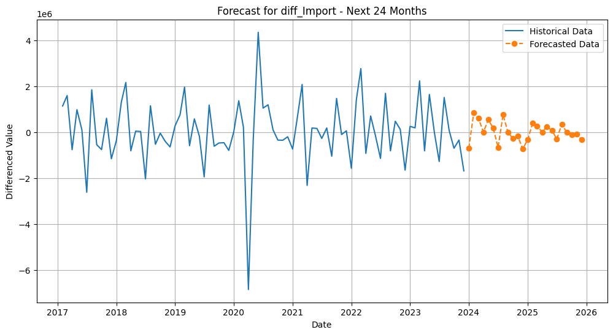

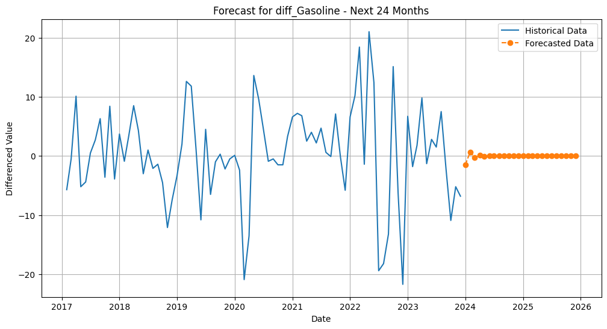

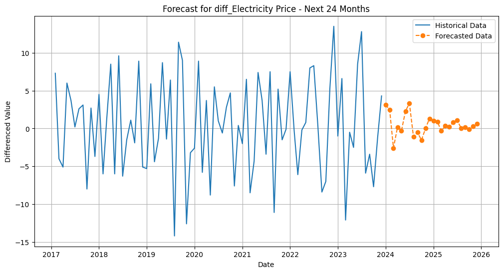

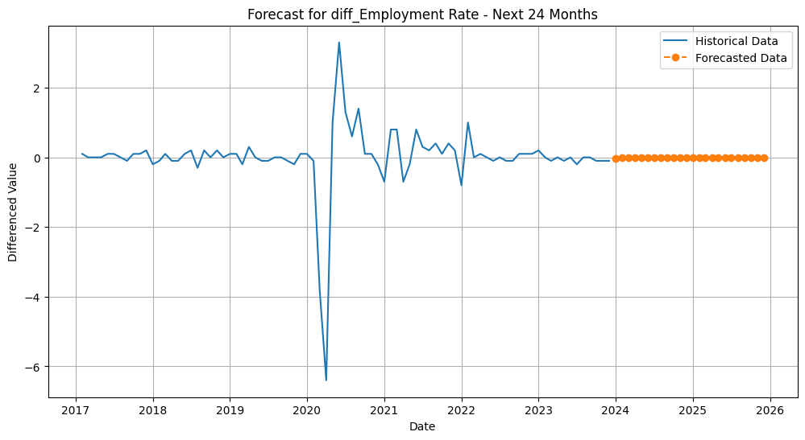

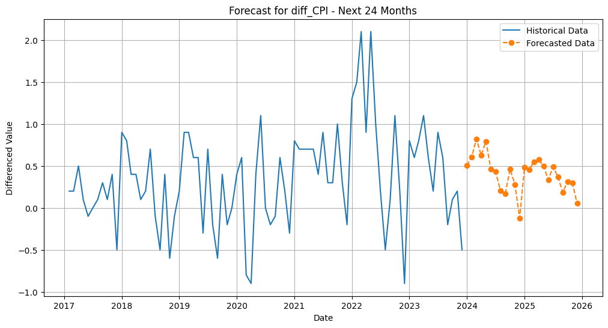

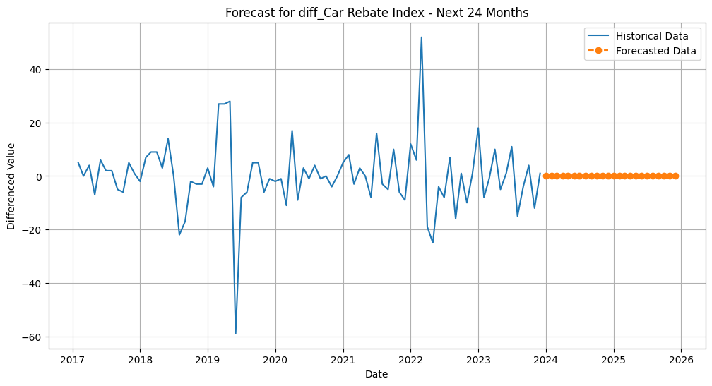

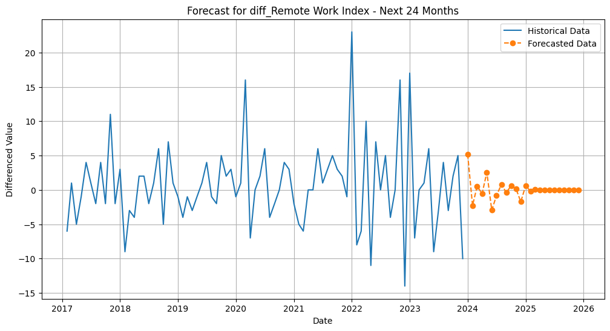

```python
# Plotting each feature
for feature in df_differenced.columns.drop('Month'):
    plt.figure(figsize=(12, 6))
    plt.plot(df_differenced['Month'], df_differenced[feature], label='Historical Data')
    plt.plot(future_dates, predictions[feature], label='Forecasted Data', linestyle='--', marker='o')
    plt.title(f'Forecast for {feature} - Next 24 Months')
    plt.xlabel('Date')
    plt.ylabel('Differenced Value')
    plt.legend()
    plt.grid(True)
    plt.show()
```

```python
for feature in features:
    print(predictions[feature])
```

```
83    -700947.013526
84     846221.448010
85     602666.561516
86       3904.935638
87     541814.461438
88     171931.456173
89    -665389.486790
90     761576.754832
91     -15087.927694
92    -271704.789381
93    -176054.836693
94    -734499.134746
95    -325149.828388
96     388974.343667
97     264869.721772
```

[output cut: 160 more lines]

```python
features
```

```
Index(['diff_Import', 'diff_Gasoline', 'diff_Electricity Price',
       'diff_Employment Rate', 'diff_CPI', 'diff_Car Rebate Index',
       'diff_Remote Work Index'],
      dtype='object')
```

```python
# Create a DataFrame for the predictions
pred_df = pd.DataFrame(predictions, index=future_dates)
```

#### 3.2 Extend the Future DataFrame

```python
feature_mapping = {
    'diff_Import': 'Import',
    'diff_Gasoline': 'Gasoline',
    'diff_Electricity Price': 'Electricity Price',
    'diff_Employment Rate': 'Employment Rate',
    'diff_CPI': 'CPI',
    'diff_Car Rebate Index': 'Car Rebate Index',
    'diff_Remote Work Index': 'Remote Work Index'
}
```

```python
# Initialize an empty dictionary to store forecasted values for each original feature name
forecasted_values = {original: [] for original in feature_mapping.values()}
```

```python
last_known_values = df_canada_data.iloc[-1]

# Iterate through each predicted difference feature
for diff_feature, original_feature in feature_mapping.items():
    # Start with the last known actual value from the original data
    last_value = last_known_values[original_feature]

    # Iterate over the predicted differences and accumulate them to the last known value
    for diff in predictions[diff_feature]:
        last_value += diff
        forecasted_values[original_feature].append(last_value)
```

```python
forecast_df = pd.DataFrame(forecasted_values, index=future_dates)
forecast_df['Month'] = forecast_df.index  # Ensure 'Month' is added for merging
forecast_df # Predicted regressors
```

|  | Import | Gasoline | Electricity Price | Employment Rate | CPI | Car Rebate Index | Remote Work Index | Month |
| --- | --- | --- | --- | --- | --- | --- | --- | --- |
| 2024-01-01 | 9.796558e+06 | 143.920576 | 136.847845 | 61.670438 | 158.803425 | 27.0 | 91.196020 | 2024-01-01 |
| 2024-02-01 | 1.064278e+07 | 144.606842 | 139.283097 | 61.670438 | 159.410404 | 27.0 | 88.911978 | 2024-02-01 |
| 2024-03-01 | 1.124545e+07 | 144.288501 | 136.701122 | 61.670438 | 160.231451 | 27.0 | 89.458999 | 2024-03-01 |
| 2024-04-01 | 1.124935e+07 | 144.436171 | 136.869492 | 61.670438 | 160.858384 | 27.0 | 88.888559 | 2024-04-01 |
| 2024-05-01 | 1.179117e+07 | 144.367671 | 136.563664 | 61.670438 | 161.652250 | 27.0 | 91.447580 | 2024-05-01 |
| 2024-06-01 | 1.196310e+07 | 144.399447 | 138.865922 | 61.670438 | 162.112086 | 27.0 | 88.505491 | 2024-06-01 |
| 2024-07-01 | 1.129771e+07 | 144.384707 | 142.187705 | 61.670438 | 162.543456 | 27.0 | 87.669836 | 2024-07-01 |
| 2024-08-01 | 1.205928e+07 | 144.391544 | 141.075742 | 61.670438 | 162.751657 | 27.0 | 88.479753 | 2024-08-01 |
| 2024-09-01 | 1.204420e+07 | 144.388372 | 140.556525 | 61.670438 | 162.921964 | 27.0 | 88.069490 | 2024-09-01 |
| 2024-10-01 | 1.177249e+07 | 144.389844 | 139.017784 | 61.670438 | 163.383447 | 27.0 | 88.700541 | 2024-10-01 |
| 2024-11-01 | 1.159644e+07 | 144.389161 | 139.020185 | 61.670438 | 163.663182 | 27.0 | 88.873913 | 2024-11-01 |
| 2024-12-01 | 1.086194e+07 | 144.389478 | 140.326629 | 61.670438 | 163.542361 | 27.0 | 87.140282 | 2024-12-01 |
| 2025-01-01 | 1.053679e+07 | 144.389331 | 141.359898 | 61.670438 | 164.023574 | 27.0 | 87.776387 | 2025-01-01 |
| 2025-02-01 | 1.092576e+07 | 144.389399 | 142.224212 | 61.670438 | 164.482045 | 27.0 | 87.542987 | 2025-02-01 |
| 2025-03-01 | 1.119063e+07 | 144.389367 | 141.898948 | 61.670438 | 165.032179 | 27.0 | 87.628626 | 2025-03-01 |
| 2025-04-01 | 1.119702e+07 | 144.389382 | 142.225788 | 61.670438 | 165.608010 | 27.0 | 87.597203 | 2025-04-01 |
| 2025-05-01 | 1.143733e+07 | 144.389375 | 142.440196 | 61.670438 | 166.107034 | 27.0 | 87.608733 | 2025-05-01 |
| 2025-06-01 | 1.151665e+07 | 144.389378 | 143.272977 | 61.670438 | 166.443153 | 27.0 | 87.604503 | 2025-06-01 |
| 2025-07-01 | 1.121709e+07 | 144.389377 | 144.347487 | 61.670438 | 166.931338 | 27.0 | 87.606055 | 2025-07-01 |
| 2025-08-01 | 1.155959e+07 | 144.389378 | 144.370761 | 61.670438 | 167.303280 | 27.0 | 87.605485 | 2025-08-01 |
| 2025-09-01 | 1.155222e+07 | 144.389377 | 144.534574 | 61.670438 | 167.486150 | 27.0 | 87.605694 | 2025-09-01 |
| 2025-10-01 | 1.143093e+07 | 144.389377 | 144.456660 | 61.670438 | 167.800021 | 27.0 | 87.605618 | 2025-10-01 |
| 2025-11-01 | 1.135170e+07 | 144.389377 | 144.744149 | 61.670438 | 168.097060 | 27.0 | 87.605646 | 2025-11-01 |
| 2025-12-01 | 1.102267e+07 | 144.389377 | 145.340824 | 61.670438 | 168.148942 | 27.0 | 87.605635 | 2025-12-01 |

```python
# Append the forecasted DataFrame to the original DataFrame
df_canada_data = pd.concat([df_canada_data, forecast_df]).reset_index(drop=True)
```

```python
df_canada_data
```

|  | Month | Vehicle Sales | Import | Gasoline | Electricity Price | Employment Rate | CPI | Car Rebate Index | Remote Work Index |
| --- | --- | --- | --- | --- | --- | --- | --- | --- | --- |
| 0 | 2017-01-01 | 112996.0 | 7.957105e+06 | 112.200000 | 102.200000 | 61.600000 | 129.500000 | 16.0 | 37.000000 |
| 1 | 2017-02-01 | 125284.0 | 9.095184e+06 | 106.500000 | 109.500000 | 61.700000 | 129.700000 | 21.0 | 31.000000 |
| 2 | 2017-03-01 | 190744.0 | 1.068698e+07 | 106.000000 | 105.500000 | 61.700000 | 129.900000 | 21.0 | 32.000000 |
| 3 | 2017-04-01 | 200291.0 | 9.925780e+06 | 116.100000 | 100.400000 | 61.700000 | 130.400000 | 25.0 | 27.000000 |
| 4 | 2017-05-01 | 220436.0 | 1.090398e+07 | 110.900000 | 106.400000 | 61.700000 | 130.500000 | 18.0 | 26.000000 |
| ... | ... | ... | ... | ... | ... | ... | ... | ... | ... |
| 103 | 2025-08-01 | NaN | 1.155959e+07 | 144.389378 | 144.370761 | 61.670438 | 167.303280 | 27.0 | 87.605485 |
| 104 | 2025-09-01 | NaN | 1.155222e+07 | 144.389377 | 144.534574 | 61.670438 | 167.486150 | 27.0 | 87.605694 |
| 105 | 2025-10-01 | NaN | 1.143093e+07 | 144.389377 | 144.456660 | 61.670438 | 167.800021 | 27.0 | 87.605618 |
| 106 | 2025-11-01 | NaN | 1.135170e+07 | 144.389377 | 144.744149 | 61.670438 | 168.097060 | 27.0 | 87.605646 |
| 107 | 2025-12-01 | NaN | 1.102267e+07 | 144.389377 | 145.340824 | 61.670438 | 168.148942 | 27.0 | 87.605635 |

108 rows × 9 columns

#### 3.3 Fill in the target variable - Vehicle Sales

The data is from the baseline model ARIMA

```python
# List of predicted values
predicted_sales = [
    132683.668106, 136096.347608, 144631.824878, 147105.408868, 143694.406214, 145551.188526, 142489.447078, 143285.725305, 144022.205470,
    142934.518321, 143269.025666, 140602.447018, 141597.503154, 143644.502253, 144592.190047, 145028.457423, 145228.771968, 145320.638104,
    145362.745815, 145382.041461, 145390.882582, 145394.933304, 145396.789173, 145397.639444
]

# Generate a date range for predictions
future_dates = pd.date_range(start='2024-01-01', periods=24, freq='MS')

# Create a DataFrame for the new predictions
df_predictions = pd.DataFrame({
    'Month': future_dates,
    'Vehicle Sales': predicted_sales
})
df_predictions
```

|  | Month | Vehicle Sales |
| --- | --- | --- |
| 0 | 2024-01-01 | 132683.668106 |
| 1 | 2024-02-01 | 136096.347608 |
| 2 | 2024-03-01 | 144631.824878 |
| 3 | 2024-04-01 | 147105.408868 |
| 4 | 2024-05-01 | 143694.406214 |
| 5 | 2024-06-01 | 145551.188526 |
| 6 | 2024-07-01 | 142489.447078 |
| 7 | 2024-08-01 | 143285.725305 |
| 8 | 2024-09-01 | 144022.205470 |
| 9 | 2024-10-01 | 142934.518321 |
| 10 | 2024-11-01 | 143269.025666 |
| 11 | 2024-12-01 | 140602.447018 |
| 12 | 2025-01-01 | 141597.503154 |
| 13 | 2025-02-01 | 143644.502253 |
| 14 | 2025-03-01 | 144592.190047 |
| 15 | 2025-04-01 | 145028.457423 |
| 16 | 2025-05-01 | 145228.771968 |
| 17 | 2025-06-01 | 145320.638104 |
| 18 | 2025-07-01 | 145362.745815 |
| 19 | 2025-08-01 | 145382.041461 |
| 20 | 2025-09-01 | 145390.882582 |
| 21 | 2025-10-01 | 145394.933304 |
| 22 | 2025-11-01 | 145396.789173 |
| 23 | 2025-12-01 | 145397.639444 |

```python
# Set 'Month' as the index for both DataFrames
df_canada_data.set_index('Month',inplace=True)
df_predictions.set_index('Month',inplace=True)

# Update the 'Vehicle Sales' in df_canada_data with values from df_predictions
df_canada_data['Vehicle Sales'].update(df_predictions['Vehicle Sales'])

# Reset the index if needed to move 'Month' back to a column
df_canada_data.reset_index(inplace=True)

# Check the DataFrame to confirm the update
print(df_canada_data.tail(24))  # Displaying the last two years to verify the updates
```

```
         Month  Vehicle Sales        Import    Gasoline  Electricity Price  \
84  2024-01-01  132683.668106  9.796558e+06  143.920576         136.847845
85  2024-02-01  136096.347608  1.064278e+07  144.606842         139.283097
86  2024-03-01  144631.824878  1.124545e+07  144.288501         136.701122
87  2024-04-01  147105.408868  1.124935e+07  144.436171         136.869492
88  2024-05-01  143694.406214  1.179117e+07  144.367671         136.563664
89  2024-06-01  145551.188526  1.196310e+07  144.399447         138.865922
90  2024-07-01  142489.447078  1.129771e+07  144.384707         142.187705
91  2024-08-01  143285.725305  1.205928e+07  144.391544         141.075742
92  2024-09-01  144022.205470  1.204420e+07  144.388372         140.556525
93  2024-10-01  142934.518321  1.177249e+07  144.389844         139.017784
94  2024-11-01  143269.025666  1.159644e+07  144.389161         139.020185
95  2024-12-01  140602.447018  1.086194e+07  144.389478         140.326629
96  2025-01-01  141597.503154  1.053679e+07  144.389331         141.359898
97  2025-02-01  143644.502253  1.092576e+07  144.389399         142.224212
```

[output cut: 36 more lines]